# Assignment # 5 - STAT545

Kimberly Sharpe

Loading tidyverse, ggplot and gapminder packages for Exericse #1 and #1

```r
library(tidyverse)
library(ggplot2)
library(gapminder)
library(here)
library(forcats)
library(DT)
library(readr)
library(gridExtra)
library(ggridges)
```

# Exercise 1: Explain the value of the here package

(maximum 250 words)

The blog raised the importance of using both Rprojects and the here package. One of the benefits of using Rprojects is when you’re in a project, you don’t need to set your working directory - the directory is already where your projet is. Another benefit is that Rprojects also clears the R environment when you switch projects. The here package is useful to use with Rprojects because it makes it easier to manage sub-directories in your project (so you can more easily manage folders for Rmarkdown vs data vs other folders you’ve added). For instance, Rmarkdown sets a local working directory so you must use a longer relative path to read in data files - with here() it finds the project directory for you. Because here() allows you to read and write data without specifying every path explicitly, it allows you to work across operating systems (Mac, Windows, Linnux), which is useful for when you’re working collaboratively or when you’re interested in the reproducibility of your work.

# Exercise 2: Factor management

##### I’ve chosen to use the *gapminder dataset* for this exercise.

### Drop Oceania from the gapminder dataset

```r
class(gapminder$continent)
```

```
## [1] "factor"
```

```r
levels(gapminder$continent)
```

```
## [1] "Africa"   "Americas" "Asia"     "Europe"   "Oceania"
```

```r
gap_2 <- gapminder %>%
  filter(continent != "Oceania") %>%  ## keep everything except Oceania
  droplevels() # Using droplevels() this drops unsed from all factors (including continent and the associated countries))
  #mutate(continent = forcats::fct_drop(continent)) ## using fct_drop() to remove the level from continent

levels(gap_2$continent)
```

```
## [1] "Africa"   "Americas" "Asia"     "Europe"
```

### Reorder the levels of country or continent

First I am filtering and grouping the dataset and calculating the minimum life expectancy for 2007.

```r
gap_life <- gap_2 %>%
  filter(year == 2007) %>%
  group_by(continent) %>%
  summarize(min_lifeExp = min(lifeExp))

gap_life
```

```
## # A tibble: 4 x 2
##   continent min_lifeExp
##   <fct>           <dbl>
## 1 Africa           39.6
## 2 Americas         60.9
## 3 Asia             43.8
## 4 Europe           71.8
```

Then I am visualizing this information in a bar plot.

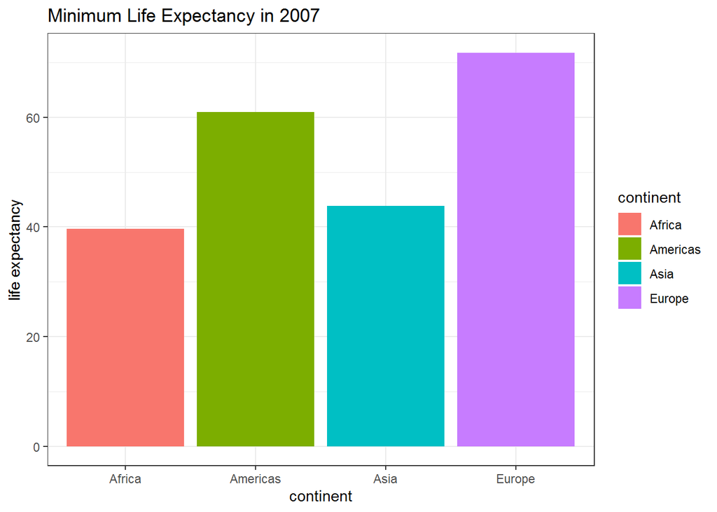

```r
gap_life %>%
  ggplot() +
  geom_col(aes(x = continent, y = min_lifeExp, fill = continent)) +
  theme_bw() +
  ggtitle("Minimum Life Expectancy in 2007") +
  labs(y = "life expectancy")
```

In the above plot, I can see that Africa has the lowest life expectancy in 2007, followed by Asia, Americans and then Europe. I want to reorder the levels of continent based on life expectancy.

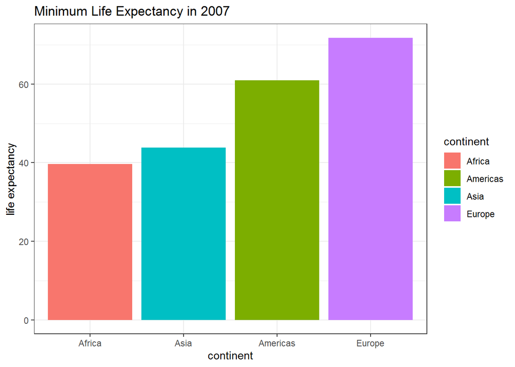

```r
gap_life %>%
  ggplot() +
  geom_col(aes(x = fct_reorder(continent, min_lifeExp), y = min_lifeExp, fill = continent)) +
  theme_bw() +
  ggtitle("Minimum Life Expectancy in 2007") +
  labs(x = "continent", y = "life expectancy")
```

I am also going to use the arrange() function to order continent from smallest to largest.

```r
gap_life %>%
  arrange(min_lifeExp)
```

```
## # A tibble: 4 x 2
##   continent min_lifeExp
##   <fct>           <dbl>
## 1 Africa           39.6
## 2 Asia             43.8
## 3 Americas         60.9
## 4 Europe           71.8
```

# Exercise 3: File input/output (I/O)

### Task: Experiment with at least one of:

- **write_csv()/read_csv() (and/or TSV friends),**
- **saveRDS()/readRDS(),**
- **dput()/dget().**

I am limiting this dataset to countries from the Amricas am looking at median GDP per capita.

```r
gapGDP <- gapminder %>%
  filter(continent == "Americas") %>%
  group_by(country) %>%
  summarize(med_GDP = median(gdpPercap))

DT::datatable(gapGDP)
```

|  | country | med_GDP |
| --- | --- | --- |
| 1 | Argentina | 9068.7844005 |
| 2 | Bolivia | 2971.0155165 |
| 3 | Brazil | 6805.2008375 |
| 4 | Canada | 22494.8376 |
| 5 | Chile | 5300.339375 |
| 6 | Colombia | 4106.6917645 |
| 7 | Costa Rica | 5446.3250345 |
| 8 | Cuba | 5891.221187 |
| 9 | Dominican Republic | 2771.540643 |
| 10 | Ecuador | 6127.4107525 |

[output cut: 15 more lines]

```r
write_csv(gapGDP, here::here("Hw 05", "gapGDP.csv"))
```

I checked in my hw 05 folder and the data was *successfully* exported!

Now to re-import the data using read_csv() and the “here” package.

```r
gapGDP_new <- read_csv(here::here("Hw 05", "gapGDP.csv"))
DT::datatable(gapGDP_new)  ## looks like the file survived the import
```

|  | country | med_GDP |
| --- | --- | --- |
| 1 | Argentina | 9068.7844005 |
| 2 | Bolivia | 2971.0155165 |
| 3 | Brazil | 6805.2008375 |
| 4 | Canada | 22494.8376 |
| 5 | Chile | 5300.339375 |
| 6 | Colombia | 4106.6917645 |
| 7 | Costa Rica | 5446.3250345 |
| 8 | Cuba | 5891.221187 |
| 9 | Dominican Republic | 2771.540643 |
| 10 | Ecuador | 6127.4107525 |

[output cut: 15 more lines]

Now that the data has been imported, I am going to reorder median GDP for countries in the Americas.

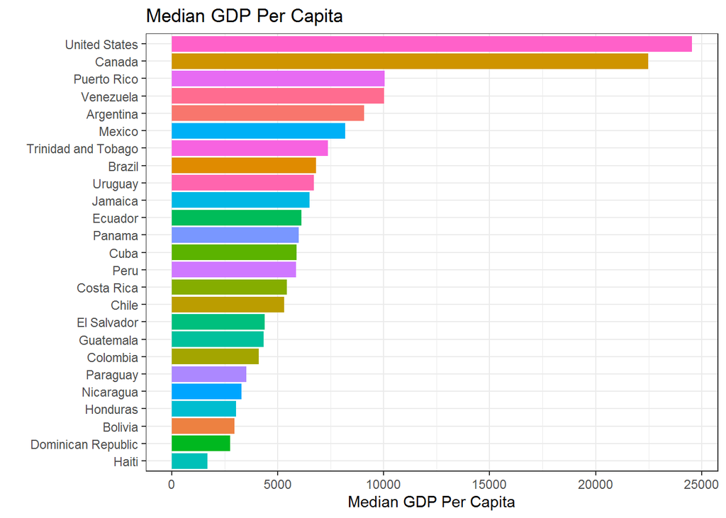

```r
gapGDP_new %>%
  ggplot() +
  geom_col(aes(x = fct_reorder(country, med_GDP), y = med_GDP, fill = country)) +
  theme_bw() +
  coord_flip() + # displaying horizontally
  theme(legend.position = "none") + # getting rid of the legend because it makes the plot so messy
  ggtitle("Median GDP Per Capita") +
  labs(x = "", y = "Median GDP Per Capita")
```

I also want to try manually reordering the values so that Brazil is first and a different colour.

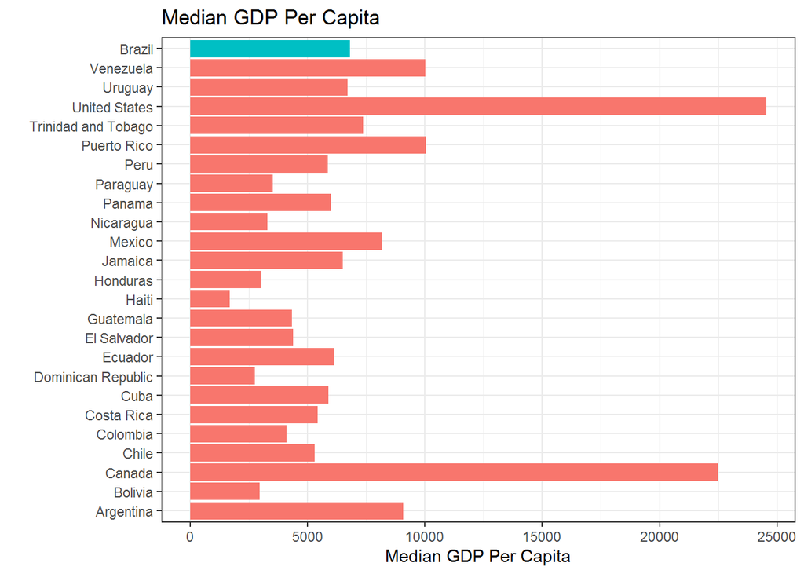

```r
gapGDP_new %>%
  ggplot() +
  geom_col(aes(x = fct_relevel(country, "Brazil", after = 25), y = med_GDP, fill = country == "Brazil")) +
  theme_bw() +
  coord_flip() + # displaying horizontally
  theme(legend.position = "none") + # getting rid of the legend because it makes the plot so messy
  ggtitle("Median GDP Per Capita") +
  labs(x = "", y = "Median GDP Per Capita")
```

# Exercise 4: Visualization design

### Improve a visualization I’ve created perior to the last week of the course

I have chosen a plot I made in *assignment #1* to improve. For that assignment, I made a boxplot of life expectancy by continent.

This is the original plot:

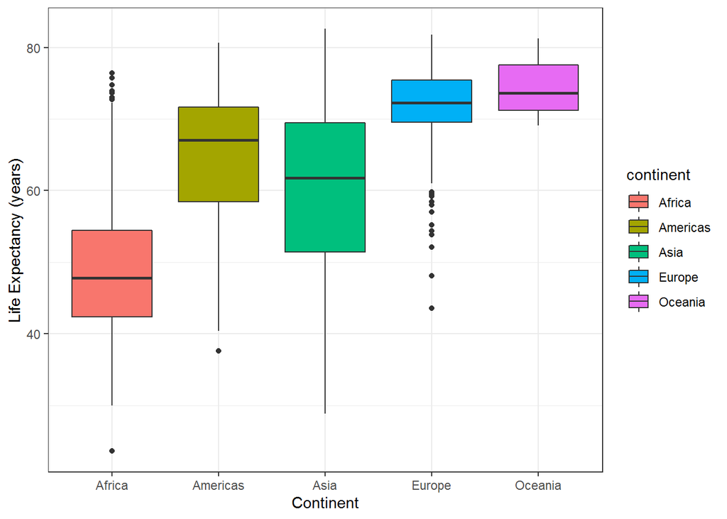

```r
(OG_plot <- ggplot(gapminder, aes(continent, lifeExp, fill=continent)) +
  geom_boxplot() +
  theme_bw() +
  xlab("Continent") +
  ylab("Life Expectancy (years)"))
```

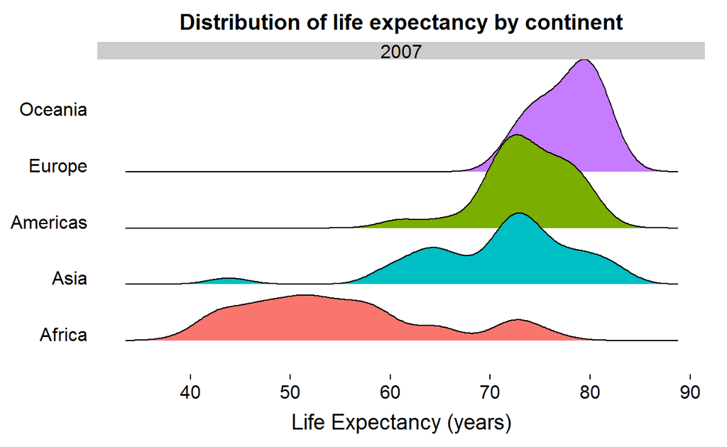

```r
(NEW_plot <- gapminder %>%
  filter(year == 2007) %>%

ggplot(aes(lifeExp, fct_reorder(continent, lifeExp), fill = continent)) +
  ggridges::geom_density_ridges(scale = 2) +
  theme_ridges(grid = FALSE, center_axis_labels = TRUE) +
  theme(plot.title = element_text(hjust = 0.5), legend.position="none") +
  xlab("Life Expectancy (years)") +
  theme(axis.title.y = element_blank()) +
  facet_grid(. ~ year) +
  ggtitle("Distribution of life expectancy by continent"))
```

I’m now plotting them side-by-side to look at the difference.

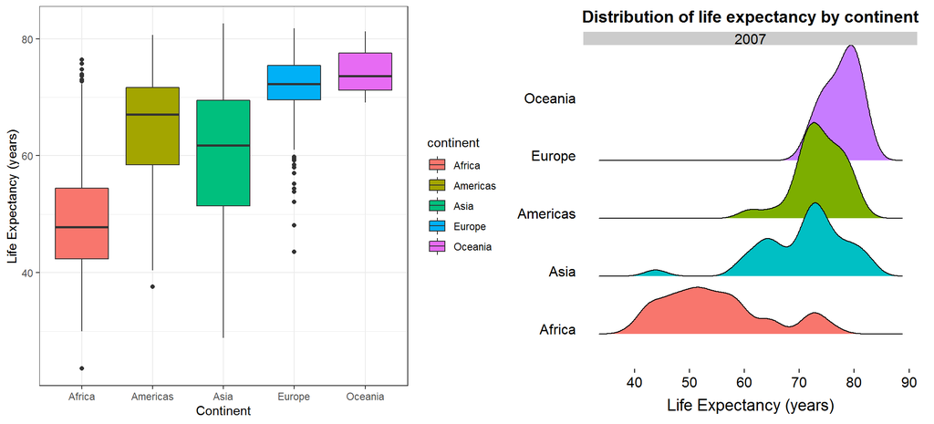

```r
gridExtra::grid.arrange(OG_plot, NEW_plot, ncol=2,
                        widths = c(3,2.5))
```

# Exercise 5: Writing figures to file

### Use ggsave() to save a plot to file.

```r
NEW_plot2 <- gapminder %>%
  filter(year == 2002) %>%

ggplot(aes(lifeExp, fct_reorder(continent, lifeExp), fill = continent)) +
  ggridges::geom_density_ridges(scale = 2) +
  theme_ridges(grid = FALSE, center_axis_labels = TRUE) +
  theme(plot.title = element_text(hjust = 0.5), legend.position="none") +
  xlab("Life Expectancy (years)") +
  theme(axis.title.y = element_blank()) +
  facet_grid(. ~ year) +
  ggtitle("Distribution of life expectancy by continent")
```

Now I will save it using ggsave() to my Hw 05 folder.

Declaring the plot is important if you want to add other diagrams - without specifying plot = " " it saves the most recent plot.

```r
ggsave(here::here("Hw 05", "Hw05 Plot1.jpg"), plot = NEW_plot2)
```

This is what the plot looks like embedded:

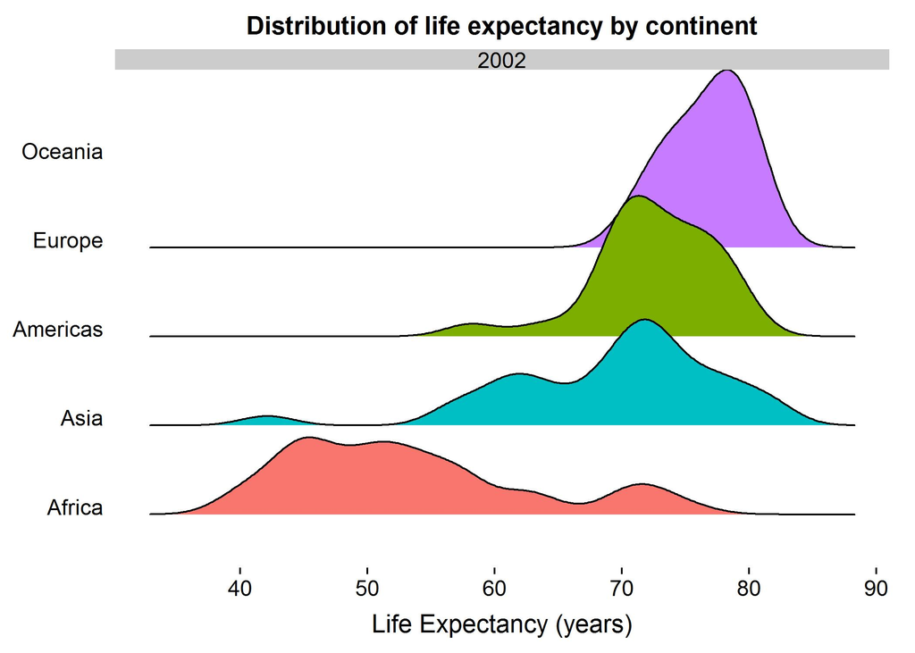

.

I can also play around with the settings of the image.

```r
ggsave(here::here("Hw 05", "Hw05 Plot2.jpg"), plot = NEW_plot2, width = 5, height = 6)
```

This is what the plot looks like embedded:

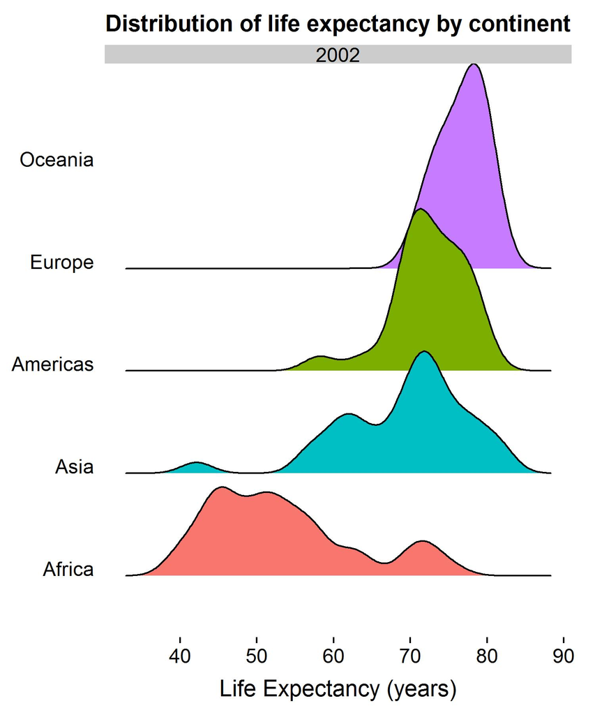

.